# ADA MidSem P2

- Sampad Kumar Kar
- MCS202215

# 0. Imports

```python
import os, sys
import pandas as pd
import numpy as np

# for plotting
import matplotlib.pyplot as plt
import seaborn as sns

# sklearn imports
from sklearn.model_selection import train_test_split
from sklearn.preprocessing import LabelEncoder, StandardScaler
from sklearn.linear_model import LogisticRegression
from sklearn.metrics import classification_report, confusion_matrix, accuracy_score, precision_score, recall_score, f1_score

# for statistical tests
from statsmodels.stats.outliers_influence import variance_inflation_factor
```

```python
# ignore warnings
import warnings
warnings.filterwarnings('ignore')
```

## 0.1 Some helper functions

```python
from pandas.api.types import is_datetime64_dtype, is_categorical_dtype

# helper function to reduce memory usage by compressing datatype
def reduce_mem_usage(df, use_float16=False):
    """
    Iterate through all the columns of a dataframe and modify the data type to reduce memory usage.
    """
    start_mem = df.memory_usage().sum() / 1024**2
    print('Memory usage of dataframe is {:.2f} MB'.format(start_mem))

    for col in df.columns:
        if is_datetime64_dtype(df[col]) or is_categorical_dtype(df[col]):
            # skip datetime type or categorical type
            continue
        col_type = df[col].dtype

        if col_type != object:
            c_min = df[col].min()
            c_max = df[col].max()
            if str(col_type)[:3] == 'int':
                if c_min > np.iinfo(np.int8).min and c_max < np.iinfo(np.int8).max:
                    df[col] = df[col].astype(np.int8)
                elif c_min > np.iinfo(np.int16).min and c_max < np.iinfo(np.int16).max:
                    df[col] = df[col].astype(np.int16)
                elif c_min > np.iinfo(np.int32).min and c_max < np.iinfo(np.int32).max:
                    df[col] = df[col].astype(np.int32)
                elif c_min > np.iinfo(np.int64).min and c_max < np.iinfo(np.int64).max:
                    df[col] = df[col].astype(np.int64)
            else:
                if use_float16 and c_min > np.finfo(np.float16).min and c_max < np.finfo(np.float16).max:
                    df[col] = df[col].astype(np.float16)
                elif c_min > np.finfo(np.float32).min and c_max < np.finfo(np.float32).max:
                    df[col] = df[col].astype(np.float32)
                else:
                    df[col] = df[col].astype(np.float64)
        else:
            df[col] = df[col].astype('object')

    end_mem = df.memory_usage().sum() / 1024**2
    print('Memory usage after optimization is: {:.2f} MB'.format(end_mem))
    print('Decreased by {:.1f}%'.format(100 * (start_mem - end_mem) / start_mem))

    return df
```

```python
# helper function to find the column with highest VIF and drop it from the dataframe, if it is greater than threshold
def drop_correlated_columns(df, vif_threshold):
    # select the columns which do not have the datatype as object
    df = df.select_dtypes(exclude=['object'])

    # variable set to True if we need to continue dropping columns
    flag = True

    while flag:
        # calculate VIF for each feature
        vif = pd.DataFrame()
        vif["features"] = df.columns
        vif["VIF"] = [variance_inflation_factor(df.values, i) for i in range(df.shape[1])]

        # select the column with highest VIF
        max_col = vif.sort_values(by=['VIF'], ascending=False)['features'].iloc[0]

        # check if the VIF is greather than threshold
        if vif[vif['features'] == max_col]['VIF'].iloc[0] > vif_threshold:
            # drop the column
            df = df.drop(max_col, axis=1)
        else:
            # if no column has VIF greater than threshold, exit the loop
            flag = False

    return vif
```

# 1. Data Loading

```python
data_dir_path = os.path.join('data', 'raw')
```

```python
# read the features
dff = pd.read_csv(os.path.join(data_dir_path, 'NUSW-NB15_features.csv'), encoding='cp1252', index_col=0)

dff
```

| No. | Name | Type | Description |
| --- | --- | --- | --- |
| 1 | srcip | nominal | Source IP address |
| 2 | sport | integer | Source port number |
| 3 | dstip | nominal | Destination IP address |
| 4 | dsport | integer | Destination port number |
| 5 | proto | nominal | Transaction protocol |
| 6 | state | nominal | Indicates to the state and its dependent proto... |
| 7 | dur | Float | Record total duration |
| 8 | sbytes | Integer | Source to destination transaction bytes |
| 9 | dbytes | Integer | Destination to source transaction bytes |
| 10 | sttl | Integer | Source to destination time to live value |
| 11 | dttl | Integer | Destination to source time to live value |
| 12 | sloss | Integer | Source packets retransmitted or dropped |
| 13 | dloss | Integer | Destination packets retransmitted or dropped |
| 14 | service | nominal | http, ftp, smtp, ssh, dns, ftp-data ,irc and ... |
| 15 | Sload | Float | Source bits per second |
| 16 | Dload | Float | Destination bits per second |
| 17 | Spkts | integer | Source to destination packet count |
| 18 | Dpkts | integer | Destination to source packet count |
| 19 | swin | integer | Source TCP window advertisement value |
| 20 | dwin | integer | Destination TCP window advertisement value |
| 21 | stcpb | integer | Source TCP base sequence number |
| 22 | dtcpb | integer | Destination TCP base sequence number |
| 23 | smeansz | integer | Mean of the ?ow packet size transmitted by the... |
| 24 | dmeansz | integer | Mean of the ?ow packet size transmitted by the... |
| 25 | trans_depth | integer | Represents the pipelined depth into the connec... |
| 26 | res_bdy_len | integer | Actual uncompressed content size of the data t... |
| 27 | Sjit | Float | Source jitter (mSec) |
| 28 | Djit | Float | Destination jitter (mSec) |
| 29 | Stime | Timestamp | record start time |
| 30 | Ltime | Timestamp | record last time |
| 31 | Sintpkt | Float | Source interpacket arrival time (mSec) |
| 32 | Dintpkt | Float | Destination interpacket arrival time (mSec) |
| 33 | tcprtt | Float | TCP connection setup round-trip time, the sum ... |
| 34 | synack | Float | TCP connection setup time, the time between th... |
| 35 | ackdat | Float | TCP connection setup time, the time between th... |
| 36 | is_sm_ips_ports | Binary | If source (1) and destination (3)IP addresses ... |
| 37 | ct_state_ttl | Integer | No. for each state (6) according to specific r... |
| 38 | ct_flw_http_mthd | Integer | No. of flows that has methods such as Get and ... |
| 39 | is_ftp_login | Binary | If the ftp session is accessed by user and pas... |
| 40 | ct_ftp_cmd | integer | No of flows that has a command in ftp session. |
| 41 | ct_srv_src | integer | No. of connections that contain the same servi... |
| 42 | ct_srv_dst | integer | No. of connections that contain the same servi... |
| 43 | ct_dst_ltm | integer | No. of connections of the same destination add... |
| 44 | ct_src_ ltm | integer | No. of connections of the same source address ... |
| 45 | ct_src_dport_ltm | integer | No of connections of the same source address (... |
| 46 | ct_dst_sport_ltm | integer | No of connections of the same destination addr... |
| 47 | ct_dst_src_ltm | integer | No of connections of the same source (1) and t... |
| 48 | attack_cat | nominal | The name of each attack category. In this data... |
| 49 | Label | binary | 0 for normal and 1 for attack records |

```python
# read the data, while setting the 'Name' column as the column names and 'Type' column as the data type of each column from the dff dataframe
df1 = reduce_mem_usage(pd.read_csv(os.path.join(data_dir_path, 'UNSW-NB15_1.csv'), names=dff['Name'].values))
df2 = reduce_mem_usage(pd.read_csv(os.path.join(data_dir_path, 'UNSW-NB15_2.csv'), names=dff['Name'].values))
df3 = reduce_mem_usage(pd.read_csv(os.path.join(data_dir_path, 'UNSW-NB15_3.csv'), names=dff['Name'].values))
df4 = reduce_mem_usage(pd.read_csv(os.path.join(data_dir_path, 'UNSW-NB15_4.csv'), names=dff['Name'].values))

# concatenate the dataframes into a single dataframe
df = pd.concat([df1, df2, df3, df4], ignore_index=True)

df.head()
```

```
Memory usage of dataframe is 261.69 MB
Memory usage after optimization is: 116.16 MB
Decreased by 55.6%
Memory usage of dataframe is 261.69 MB
Memory usage after optimization is: 122.83 MB
Decreased by 53.1%
Memory usage of dataframe is 261.69 MB
Memory usage after optimization is: 122.83 MB
Decreased by 53.1%
Memory usage of dataframe is 164.51 MB
Memory usage after optimization is: 77.22 MB
Decreased by 53.1%
```

|  | srcip | sport | dstip | dsport | proto | state | dur | sbytes | dbytes | sttl | ... | ct_ftp_cmd | ct_srv_src | ct_srv_dst | ct_dst_ltm | ct_src_ ltm | ct_src_dport_ltm | ct_dst_sport_ltm | ct_dst_src_ltm | attack_cat | Label |
| --- | --- | --- | --- | --- | --- | --- | --- | --- | --- | --- | --- | --- | --- | --- | --- | --- | --- | --- | --- | --- | --- |
| 0 | 59.166.0.0 | 1390 | 149.171.126.6 | 53 | udp | CON | 0.001055 | 132 | 164 | 31 | ... | 0 | 3 | 7 | 1 | 3 | 1 | 1 | 1 | NaN | 0 |
| 1 | 59.166.0.0 | 33661 | 149.171.126.9 | 1024 | udp | CON | 0.036133 | 528 | 304 | 31 | ... | 0 | 2 | 4 | 2 | 3 | 1 | 1 | 2 | NaN | 0 |
| 2 | 59.166.0.6 | 1464 | 149.171.126.7 | 53 | udp | CON | 0.001119 | 146 | 178 | 31 | ... | 0 | 12 | 8 | 1 | 2 | 2 | 1 | 1 | NaN | 0 |
| 3 | 59.166.0.5 | 3593 | 149.171.126.5 | 53 | udp | CON | 0.001209 | 132 | 164 | 31 | ... | 0 | 6 | 9 | 1 | 1 | 1 | 1 | 1 | NaN | 0 |
| 4 | 59.166.0.3 | 49664 | 149.171.126.0 | 53 | udp | CON | 0.001169 | 146 | 178 | 31 | ... | 0 | 7 | 9 | 1 | 1 | 1 | 1 | 1 | NaN | 0 |

5 rows × 49 columns

```python
# print the shape of the dataframe
df.shape
```

```
(2540047, 49)
```

```python
# print info about the columns
df.info()
```

```
<class 'pandas.core.frame.DataFrame'>
RangeIndex: 2540047 entries, 0 to 2540046
Data columns (total 49 columns):
 #   Column            Dtype
---  ------            -----
 0   srcip             object
 1   sport             object
 2   dstip             object
 3   dsport            object
 4   proto             object
 5   state             object
 6   dur               float32
 7   sbytes            int32
 8   dbytes            int32
 9   sttl              int16
```

[output cut: 41 more lines]

```python
df.describe()
```

|  | dur | sbytes | dbytes | sttl | dttl | sloss | dloss | Sload | Dload | Spkts | ... | ct_flw_http_mthd | is_ftp_login | ct_srv_src | ct_srv_dst | ct_dst_ltm | ct_src_ ltm | ct_src_dport_ltm | ct_dst_sport_ltm | ct_dst_src_ltm | Label |
| --- | --- | --- | --- | --- | --- | --- | --- | --- | --- | --- | --- | --- | --- | --- | --- | --- | --- | --- | --- | --- | --- |
| count | 2.540047e+06 | 2.540047e+06 | 2.540047e+06 | 2.540047e+06 | 2.540047e+06 | 2.540047e+06 | 2.540047e+06 | 2.540047e+06 | 2.540047e+06 | 2.540047e+06 | ... | 1.191902e+06 | 1.110168e+06 | 2.540047e+06 | 2.540047e+06 | 2.540047e+06 | 2.540047e+06 | 2.540047e+06 | 2.540047e+06 | 2.540047e+06 | 2.540047e+06 |
| mean | 6.587917e-01 | 4.339600e+03 | 3.642759e+04 | 6.278197e+01 | 3.076681e+01 | 5.163921e+00 | 1.632944e+01 | 3.695645e+07 | 2.450861e+06 | 3.328884e+01 | ... | 2.345856e-01 | 3.969940e-02 | 9.206988e+00 | 8.988958e+00 | 6.439103e+00 | 6.900986e+00 | 4.642139e+00 | 3.592729e+00 | 6.845886e+00 | 1.264870e-01 |
| std | 1.392493e+01 | 5.640599e+04 | 1.610960e+05 | 7.462277e+01 | 4.285089e+01 | 2.251707e+01 | 5.659474e+01 | 1.186043e+08 | 4.224863e+06 | 7.628388e+01 | ... | 7.940924e-01 | 1.996589e-01 | 1.083676e+01 | 1.082249e+01 | 8.162034e+00 | 8.205062e+00 | 8.477579e+00 | 6.174445e+00 | 1.125828e+01 | 3.323975e-01 |
| min | 0.000000e+00 | 0.000000e+00 | 0.000000e+00 | 0.000000e+00 | 0.000000e+00 | 0.000000e+00 | 0.000000e+00 | 0.000000e+00 | 0.000000e+00 | 0.000000e+00 | ... | 0.000000e+00 | 0.000000e+00 | 1.000000e+00 | 1.000000e+00 | 1.000000e+00 | 1.000000e+00 | 1.000000e+00 | 1.000000e+00 | 1.000000e+00 | 0.000000e+00 |
| 25% | 1.037000e-03 | 2.000000e+02 | 1.780000e+02 | 3.100000e+01 | 2.900000e+01 | 0.000000e+00 | 0.000000e+00 | 1.353963e+05 | 1.191594e+04 | 2.000000e+00 | ... | 0.000000e+00 | 0.000000e+00 | 2.000000e+00 | 2.000000e+00 | 2.000000e+00 | 2.000000e+00 | 1.000000e+00 | 1.000000e+00 | 1.000000e+00 | 0.000000e+00 |
| 50% | 1.586100e-02 | 1.470000e+03 | 1.820000e+03 | 3.100000e+01 | 2.900000e+01 | 3.000000e+00 | 4.000000e+00 | 5.893038e+05 | 5.893179e+05 | 1.200000e+01 | ... | 0.000000e+00 | 0.000000e+00 | 5.000000e+00 | 5.000000e+00 | 3.000000e+00 | 4.000000e+00 | 1.000000e+00 | 1.000000e+00 | 2.000000e+00 | 0.000000e+00 |
| 75% | 2.145545e-01 | 3.182000e+03 | 1.489400e+04 | 3.100000e+01 | 2.900000e+01 | 7.000000e+00 | 1.400000e+01 | 2.039923e+06 | 2.925974e+06 | 4.400000e+01 | ... | 0.000000e+00 | 0.000000e+00 | 1.000000e+01 | 1.000000e+01 | 6.000000e+00 | 7.000000e+00 | 2.000000e+00 | 1.000000e+00 | 5.000000e+00 | 0.000000e+00 |
| max | 8.786638e+03 | 1.435577e+07 | 1.465753e+07 | 2.550000e+02 | 2.540000e+02 | 5.319000e+03 | 5.507000e+03 | 5.988000e+09 | 1.287619e+08 | 1.064600e+04 | ... | 3.600000e+01 | 4.000000e+00 | 6.700000e+01 | 6.700000e+01 | 6.700000e+01 | 6.700000e+01 | 6.700000e+01 | 6.000000e+01 | 6.700000e+01 | 1.000000e+00 |

8 rows × 40 columns

# 2. Data Summarization

## 2.1 Total no. of flows.

Each flow is determined by the 5-tuple of the following features:

- `srcip`
- `sport`
- `dstip`
- `dsport`
- `proto`

```python
columns_of_interest = ['srcip', 'sport', 'dstip', 'dsport', 'proto']
unique_flows = df[columns_of_interest].drop_duplicates()

# extract the no. of unique flows
num_unique_flows = unique_flows.shape[0]
print("Total no. of unique flows: ", num_unique_flows)
```

```
Total no. of unique flows:  1965893
```

## 2.2 Total flow duration.

Total flow duration is just the sum of all the entries in the `dur` column.

```python
# total flow duration
total_flow_duration = df['dur'].sum()
print("Total flow duration (in s): ", total_flow_duration)
```

```
Total flow duration (in s):  1673361.9
```

# 3. Data Preprocessing

## 3.1 Handling Missing Values

```python
# check for missing values and only display the columns with non zero missing values
df.isnull().sum()[df.isnull().sum() > 0]
```

```
ct_flw_http_mthd    1348145
is_ftp_login        1429879
attack_cat          2218764
dtype: int64
```

```python
# display the proportion of missing values
df.isnull().sum()[df.isnull().sum() > 0] / df.shape[0]
```

```
ct_flw_http_mthd    0.530756
is_ftp_login        0.562934
attack_cat          0.873513
dtype: float64
```

Based on the information above we choose to employ the following strategy to handle missing values corresponding to these 3 columns:

- `ct_flw_http_mthd`: This columns contains integers, so we impute the missing values with the closest integer to the mean.
- `is_ftp_login`: This is a boolean columnm, so we impute the missing values with the mode.
- `attack_cat`: This is a nominal column with distict categories and this column also has `87.35%` of it's values missing. So we drop this column.

```python
# impute with closest integer to the mean
mean_ct_flw_http_mthd = df['ct_flw_http_mthd'].mean()
df['ct_flw_http_mthd'].fillna(round(mean_ct_flw_http_mthd), inplace=True)

# impute with mode
mode_is_ftp_login = df['is_ftp_login'].mode()[0]
df['is_ftp_login'].fillna(mode_is_ftp_login, inplace=True)

# drop column
df.drop('attack_cat', axis=1, inplace=True)
```

```python
# check for missing values and only display the columns with non zero missing values
df.isnull().sum()[df.isnull().sum() > 0]
```

```
Series([], dtype: int64)
```

So, we do not have missing values anymore.

## 3.2 Check for Multicollinearity

### 3.2.1 Correlation Matrix

We check for multicollinearity using the correlation matrix. Columns with correlation values close to `1` or `-1` are considered to be highly correlated.

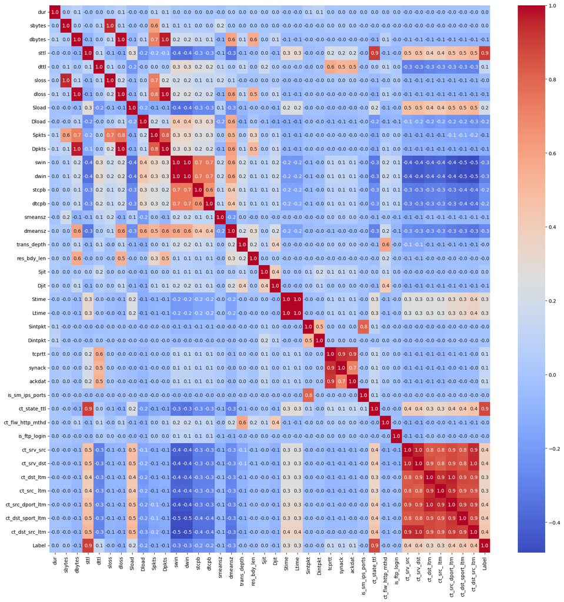

```python
# compute the correlation matrix for the numerical features
corr_matrix = df.select_dtypes(exclude=['object']).corr()

# plot the heatmap
plt.figure(figsize=(20, 20))
sns.heatmap(corr_matrix, annot=True, cmap='coolwarm', fmt=".1f")
plt.show()
```

### 3.2.2 Variance Inflation Factor (VIF)

We also check for multicollinearity using the VIF values. Columns with VIF values greater than `10` are considered to be highly correlated.

Here is how we calculate the VIF values:

$$VIF_i = \frac{1}{1 - R_i^2}$$

where $R_i^2$ is the $R^2$ value of the regression of the $i^{th}$ feature on all the other features.

We drop the variables one after another, in decreasing order of their VIF values, until all the VIF values are less than `10` for the remaining columns. For this we use the helper function `drop_correlated_columns`.

```python
%%time

# we set a threshold of 10
threshold = 10
vif = drop_correlated_columns(df, 10)
vif
```

```
CPU times: user 5h 49s, sys: 28min 9s, total: 5h 28min 59s
Wall time: 57min 40s
```

|  | features | VIF |
| --- | --- | --- |
| 0 | dur | 1.022104 |
| 1 | sbytes | 4.254992 |
| 2 | dbytes | 7.467053 |
| 3 | dttl | 2.017366 |
| 4 | Sload | 1.423300 |
| 5 | Dload | 2.128370 |
| 6 | Spkts | 9.827260 |
| 7 | swin | 4.917358 |
| 8 | stcpb | 2.338797 |
| 9 | dtcpb | 2.338982 |
| 10 | smeansz | 1.405013 |
| 11 | dmeansz | 4.452056 |
| 12 | trans_depth | 1.712197 |
| 13 | res_bdy_len | 1.632796 |
| 14 | Sjit | 1.256313 |
| 15 | Djit | 1.596539 |
| 16 | Ltime | 0.000004 |
| 17 | Dintpkt | 1.052766 |
| 18 | synack | 2.184516 |
| 19 | ackdat | 2.211254 |
| 20 | is_sm_ips_ports | 1.070685 |
| 21 | ct_state_ttl | 4.862982 |
| 22 | ct_flw_http_mthd | 1.653777 |
| 23 | is_ftp_login | 1.118511 |
| 24 | ct_srv_src | 4.631355 |
| 25 | ct_src_ ltm | 4.837234 |
| 26 | ct_dst_sport_ltm | 5.361229 |
| 27 | Label | 5.056842 |

```python
# columns to remove from the dataframe
non_object_columns = [col for col in df.columns if df[col].dtype != 'object']
columns_to_remove = [col for col in non_object_columns if (col not in vif['features'].values)]
```

```python
columns_to_remove
```

```
['sttl',
 'sloss',
 'dloss',
 'Dpkts',
 'dwin',
 'Stime',
 'Sintpkt',
 'tcprtt',
 'ct_srv_dst',
 'ct_dst_ltm',
 'ct_src_dport_ltm',
 'ct_dst_src_ltm']
```

We remove the above listed columns from the dataframe due to them having high multicollinearity.

```python
# columns of dataframe before removing correlated columns
df.columns
```

```
Index(['srcip', 'sport', 'dstip', 'dsport', 'proto', 'state', 'dur', 'sbytes',
       'dbytes', 'sttl', 'dttl', 'sloss', 'dloss', 'service', 'Sload', 'Dload',
       'Spkts', 'Dpkts', 'swin', 'dwin', 'stcpb', 'dtcpb', 'smeansz',
       'dmeansz', 'trans_depth', 'res_bdy_len', 'Sjit', 'Djit', 'Stime',
       'Ltime', 'Sintpkt', 'Dintpkt', 'tcprtt', 'synack', 'ackdat',
       'is_sm_ips_ports', 'ct_state_ttl', 'ct_flw_http_mthd', 'is_ftp_login',
       'ct_ftp_cmd', 'ct_srv_src', 'ct_srv_dst', 'ct_dst_ltm', 'ct_src_ ltm',
       'ct_src_dport_ltm', 'ct_dst_sport_ltm', 'ct_dst_src_ltm', 'Label'],
      dtype='object')
```

```python
# remove the columns from the dataframe
df.drop(columns_to_remove, axis=1, inplace=True)

# columns of dataframe after removing correlated columns
df.columns
```

```
Index(['srcip', 'sport', 'dstip', 'dsport', 'proto', 'state', 'dur', 'sbytes',
       'dbytes', 'dttl', 'service', 'Sload', 'Dload', 'Spkts', 'swin', 'stcpb',
       'dtcpb', 'smeansz', 'dmeansz', 'trans_depth', 'res_bdy_len', 'Sjit',
       'Djit', 'Ltime', 'Dintpkt', 'synack', 'ackdat', 'is_sm_ips_ports',
       'ct_state_ttl', 'ct_flw_http_mthd', 'is_ftp_login', 'ct_ftp_cmd',
       'ct_srv_src', 'ct_src_ ltm', 'ct_dst_sport_ltm', 'Label'],
      dtype='object')
```

## 3.3 Handling Categorical Variables

```python
# we check all the columns with datatype as object
df_nominal = df.select_dtypes(include=['object'])

df_nominal.head()
```

|  | srcip | sport | dstip | dsport | proto | state | service | ct_ftp_cmd |
| --- | --- | --- | --- | --- | --- | --- | --- | --- |
| 0 | 59.166.0.0 | 1390 | 149.171.126.6 | 53 | udp | CON | dns | 0 |
| 1 | 59.166.0.0 | 33661 | 149.171.126.9 | 1024 | udp | CON | - | 0 |
| 2 | 59.166.0.6 | 1464 | 149.171.126.7 | 53 | udp | CON | dns | 0 |
| 3 | 59.166.0.5 | 3593 | 149.171.126.5 | 53 | udp | CON | dns | 0 |
| 4 | 59.166.0.3 | 49664 | 149.171.126.0 | 53 | udp | CON | dns | 0 |

### 3.3.1 Handling the target variable

In this dataset, the `service` column is the target variable. This is of object type. We first find all the unique values in this column and then encode them.

```python
# check the unique values in 'service' column
df_nominal['service'].value_counts()
```

```
service
-           1246397
dns          781668
http         206273
ftp-data     125783
smtp          81645
ftp           49090
ssh           47160
pop3           1533
dhcp            172
ssl             142
snmp            113
radius           40
irc              31
Name: count, dtype: int64
```

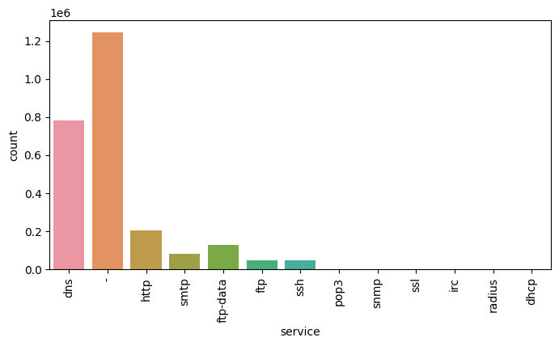

```python
# plot a barchart for 'service' column counts
plt.figure(figsize=(8, 4))
sns.countplot(x='service', data=df_nominal)
plt.xticks(rotation=90)
plt.show()
```

```python
# we use the unique values in 'service' column as class labels
class_labels = df_nominal['service'].unique()
class_labels
```

```
array(['dns', '-', 'http', 'smtp', 'ftp-data', 'ftp', 'ssh', 'pop3',
       'snmp', 'ssl', 'irc', 'radius', 'dhcp'], dtype=object)
```

### 3.3.2 Label Encoding the nominal columns

```python
# select the columns of interest (columns in df_nominal except 'service' column)
nominal_columns = [col for col in df_nominal.columns if col != 'service']
nominal_columns
```

```
['srcip', 'sport', 'dstip', 'dsport', 'proto', 'state', 'ct_ftp_cmd']
```

```python
# columns made up of multiple datatypes
compound_columns = ['sport', 'dsport', 'ct_ftp_cmd']
```

```python
le = LabelEncoder()

df_processed = df.copy()

# iterate through the columns of interest
for col in nominal_columns:
    if col in compound_columns:
        # convert the column to string datatype
        df_processed[col] = df_processed[col].astype(str)
        # fit the label encoder on the column
        df_processed[col] = le.fit_transform(df_processed[col])
    else:
        # fit the label encoder on the column
        df_processed[col] = le.fit_transform(df_processed[col])


df_processed.head()
```

|  | srcip | sport | dstip | dsport | proto | state | dur | sbytes | dbytes | dttl | ... | ackdat | is_sm_ips_ports | ct_state_ttl | ct_flw_http_mthd | is_ftp_login | ct_ftp_cmd | ct_srv_src | ct_src_ ltm | ct_dst_sport_ltm | Label |
| --- | --- | --- | --- | --- | --- | --- | --- | --- | --- | --- | --- | --- | --- | --- | --- | --- | --- | --- | --- | --- | --- |
| 0 | 33 | 4276 | 24 | 47344 | 120 | 2 | 0.001055 | 132 | 164 | 29 | ... | 0.0 | 0 | 0 | 0.0 | 0.0 | 1 | 3 | 3 | 1 | 0 |
| 1 | 33 | 26036 | 27 | 253 | 120 | 2 | 0.036133 | 528 | 304 | 29 | ... | 0.0 | 0 | 0 | 0.0 | 0.0 | 1 | 2 | 3 | 1 | 0 |
| 2 | 39 | 5091 | 25 | 47344 | 120 | 2 | 0.001119 | 146 | 178 | 29 | ... | 0.0 | 0 | 0 | 0.0 | 0.0 | 1 | 12 | 2 | 1 | 0 |
| 3 | 38 | 28534 | 23 | 47344 | 120 | 2 | 0.001209 | 132 | 164 | 29 | ... | 0.0 | 0 | 0 | 0.0 | 0.0 | 1 | 6 | 1 | 1 | 0 |
| 4 | 36 | 43654 | 8 | 47344 | 120 | 2 | 0.001169 | 146 | 178 | 29 | ... | 0.0 | 0 | 0 | 0.0 | 0.0 | 1 | 7 | 1 | 1 | 0 |

5 rows × 36 columns

```python
df_processed.info()
```

```
<class 'pandas.core.frame.DataFrame'>
RangeIndex: 2540047 entries, 0 to 2540046
Data columns (total 36 columns):
 #   Column            Dtype
---  ------            -----
 0   srcip             int64
 1   sport             int64
 2   dstip             int64
 3   dsport            int64
 4   proto             int64
 5   state             int64
 6   dur               float32
 7   sbytes            int32
 8   dbytes            int32
 9   dttl              int16
```

[output cut: 28 more lines]

### 3.3.3 Splitting Features and Target

```python
# we split the data into features and labels
features = df_processed.drop('service', axis=1)
labels = df_processed['service']

# print the shape of features and labels
print("Shape of features: ", features.shape)
print("Shape of labels: ", labels.shape)
```

```
Shape of features:  (2540047, 35)
Shape of labels:  (2540047,)
```

We have encoded all the nominal columns using the `LabelEncoder`. Now, we need to use `StandardScaler` to scale the data.

```python
# scale the features
scaler = StandardScaler()
features_scaled = scaler.fit_transform(features)
```

## 3.4 Train-Test Split

We split the data into training and testing sets using the `train_test_split` function from `sklearn.model_selection`. We use a `test_size` of `0.2` and use stratified sampling to ensure that the distribution of the target variable is the same in both the training and testing sets.

```python
# stratified split of data into train and test sets
X_train, X_test, y_train, y_test = train_test_split(features_scaled, labels, test_size=0.2, random_state=42, stratify=labels)
```

```python
# check the shape of train and test sets
print("Shape of X_train: ", X_train.shape)
print("Shape of y_train: ", y_train.shape)

print("Shape of X_test: ", X_test.shape)
print("Shape of y_test: ", y_test.shape)
```

```
Shape of X_train:  (2032037, 35)
Shape of y_train:  (2032037,)
Shape of X_test:  (508010, 35)
Shape of y_test:  (508010,)
```

# 4. Model Fit and Evaluation

We fit a simple Logistic Regression model to the data. We use the `LogisticRegression` class from `sklearn.linear_model`. We use the `predict` method to predict the target variable for the test set.

```python
log_reg = LogisticRegression()

# fit the model on train data
log_reg.fit(X_train, y_train)
```

```
LogisticRegression()
```

```python
# predict on test data
y_test_pred = log_reg.predict(X_test)
```

## 4.1 Classification Report

```python
# print the classification report
print(classification_report(y_test, y_test_pred))
```

```
              precision    recall  f1-score   support

           -       0.98      0.97      0.97    249280
        dhcp       0.32      0.29      0.31        34
         dns       0.97      1.00      0.99    156334
         ftp       0.98      0.95      0.97      9818
    ftp-data       0.95      0.97      0.96     25157
        http       0.98      0.98      0.98     41255
         irc       0.00      0.00      0.00         6
        pop3       0.70      0.50      0.58       307
      radius       0.00      0.00      0.00         8
        smtp       0.98      0.97      0.97     16329
        snmp       0.00      0.00      0.00        22
         ssh       0.79      0.78      0.78      9432
         ssl       0.00      0.00      0.00        28

    accuracy                           0.97    508010
   macro avg       0.59      0.57      0.58    508010
weighted avg       0.97      0.97      0.97    508010
```

## 4.3 Accuracy Score

```python
# print the accuracy score
print("Accuracy score: ", accuracy_score(y_test, y_test_pred))
```

```
Accuracy score:  0.973600913367847
```

## 4.4 Precision Score

```python
# print the weighted precision score
print("Weighted precision score: ", precision_score(y_test, y_test_pred, average='weighted'))
```

```
Weighted precision score:  0.9734779902861929
```

## 4.5 Recall Score

```python
# print the weighted recall score
print("Weighted recall score: ", recall_score(y_test, y_test_pred, average='weighted'))
```

```
Weighted recall score:  0.973600913367847
```

We get the following scores:

- Accuracy: `97.36 %`
- Weighted Precision: `97.34 %`
- Weighted Recall: `97.36 %`